# Risk Factor Analysis

## Outcome Variable

**Outcome Variable:** whz

## Predictor Variables

**Intervention Variable:** hhwealth_quart

**Adjustment Set:**

- arm
- sex
- W_mage
- meducyrs
- feducyrs
- W_gagebrth
- W_birthwt
- W_birthlen
- W_nchldlt5
- W_parity
- delta_W_mage
- delta_meducyrs
- delta_feducyrs
- delta_W_gagebrth
- delta_W_birthwt
- delta_W_birthlen
- delta_W_nchldlt5
- delta_W_parity

## Stratifying Variables

The analysis was stratified on these variable(s):

- agecat
- studyid
- country

## Data Summary

| agecat | studyid | country | hhwealth_quart | n_cell | n | outcome_variable |
| --- | --- | --- | --- | --- | --- | --- |
| Birth | ki0047075b-MAL-ED | BANGLADESH | Wealth Q4 | 56 | 201 | whz |
| Birth | ki0047075b-MAL-ED | BANGLADESH | Wealth Q1 | 48 | 201 | whz |
| Birth | ki0047075b-MAL-ED | BANGLADESH | Wealth Q2 | 46 | 201 | whz |
| Birth | ki0047075b-MAL-ED | BANGLADESH | Wealth Q3 | 51 | 201 | whz |
| Birth | ki0047075b-MAL-ED | BRAZIL | Wealth Q4 | 10 | 57 | whz |
| Birth | ki0047075b-MAL-ED | BRAZIL | Wealth Q1 | 20 | 57 | whz |
| Birth | ki0047075b-MAL-ED | BRAZIL | Wealth Q2 | 16 | 57 | whz |
| Birth | ki0047075b-MAL-ED | BRAZIL | Wealth Q3 | 11 | 57 | whz |
| Birth | ki0047075b-MAL-ED | INDIA | Wealth Q4 | 8 | 39 | whz |
| Birth | ki0047075b-MAL-ED | INDIA | Wealth Q1 | 13 | 39 | whz |
| Birth | ki0047075b-MAL-ED | INDIA | Wealth Q2 | 9 | 39 | whz |
| Birth | ki0047075b-MAL-ED | INDIA | Wealth Q3 | 9 | 39 | whz |
| Birth | ki0047075b-MAL-ED | NEPAL | Wealth Q4 | 6 | 25 | whz |
| Birth | ki0047075b-MAL-ED | NEPAL | Wealth Q1 | 8 | 25 | whz |
| Birth | ki0047075b-MAL-ED | NEPAL | Wealth Q2 | 3 | 25 | whz |
| Birth | ki0047075b-MAL-ED | NEPAL | Wealth Q3 | 8 | 25 | whz |
| Birth | ki0047075b-MAL-ED | PERU | Wealth Q4 | 53 | 210 | whz |
| Birth | ki0047075b-MAL-ED | PERU | Wealth Q1 | 55 | 210 | whz |
| Birth | ki0047075b-MAL-ED | PERU | Wealth Q2 | 51 | 210 | whz |
| Birth | ki0047075b-MAL-ED | PERU | Wealth Q3 | 51 | 210 | whz |
| Birth | ki0047075b-MAL-ED | SOUTH AFRICA | Wealth Q4 | 17 | 95 | whz |
| Birth | ki0047075b-MAL-ED | SOUTH AFRICA | Wealth Q1 | 26 | 95 | whz |
| Birth | ki0047075b-MAL-ED | SOUTH AFRICA | Wealth Q2 | 24 | 95 | whz |
| Birth | ki0047075b-MAL-ED | SOUTH AFRICA | Wealth Q3 | 28 | 95 | whz |
| Birth | ki0047075b-MAL-ED | TANZANIA, UNITED REPUBLIC OF | Wealth Q4 | 23 | 112 | whz |
| Birth | ki0047075b-MAL-ED | TANZANIA, UNITED REPUBLIC OF | Wealth Q1 | 26 | 112 | whz |
| Birth | ki0047075b-MAL-ED | TANZANIA, UNITED REPUBLIC OF | Wealth Q2 | 30 | 112 | whz |
| Birth | ki0047075b-MAL-ED | TANZANIA, UNITED REPUBLIC OF | Wealth Q3 | 33 | 112 | whz |
| Birth | ki1000108-CMC-V-BCS-2002 | INDIA | Wealth Q4 | 32 | 86 | whz |
| Birth | ki1000108-CMC-V-BCS-2002 | INDIA | Wealth Q1 | 13 | 86 | whz |

[output cut: 178 more lines]

The following strata were considered:

- agecat: 24 months, studyid: ki0047075b-MAL-ED, country: BANGLADESH
- agecat: 24 months, studyid: ki0047075b-MAL-ED, country: BRAZIL
- agecat: 24 months, studyid: ki0047075b-MAL-ED, country: INDIA
- agecat: 24 months, studyid: ki0047075b-MAL-ED, country: NEPAL
- agecat: 24 months, studyid: ki0047075b-MAL-ED, country: PERU
- agecat: 24 months, studyid: ki0047075b-MAL-ED, country: SOUTH AFRICA
- agecat: 24 months, studyid: ki0047075b-MAL-ED, country: TANZANIA, UNITED REPUBLIC OF
- agecat: 24 months, studyid: ki1000108-CMC-V-BCS-2002, country: INDIA
- agecat: 24 months, studyid: ki1000108-IRC, country: INDIA
- agecat: 24 months, studyid: ki1017093b-PROVIDE, country: BANGLADESH
- agecat: 24 months, studyid: ki1066203-TanzaniaChild2, country: TANZANIA, UNITED REPUBLIC OF
- agecat: 24 months, studyid: ki1113344-GMS-Nepal, country: NEPAL
- agecat: 24 months, studyid: ki1114097-CONTENT, country: PERU
- agecat: 24 months, studyid: ki1135781-COHORTS, country: GUATEMALA
- agecat: 24 months, studyid: ki1135781-COHORTS, country: PHILIPPINES
- agecat: 24 months, studyid: ki1148112-LCNI-5, country: MALAWI
- agecat: 24 months, studyid: kiGH5241-JiVitA-3, country: BANGLADESH
- agecat: 24 months, studyid: kiGH5241-JiVitA-4, country: BANGLADESH
- agecat: 6 months, studyid: ki0047075b-MAL-ED, country: BANGLADESH
- agecat: 6 months, studyid: ki0047075b-MAL-ED, country: BRAZIL
- agecat: 6 months, studyid: ki0047075b-MAL-ED, country: INDIA
- agecat: 6 months, studyid: ki0047075b-MAL-ED, country: NEPAL
- agecat: 6 months, studyid: ki0047075b-MAL-ED, country: PERU
- agecat: 6 months, studyid: ki0047075b-MAL-ED, country: SOUTH AFRICA
- agecat: 6 months, studyid: ki0047075b-MAL-ED, country: TANZANIA, UNITED REPUBLIC OF
- agecat: 6 months, studyid: ki1000108-CMC-V-BCS-2002, country: INDIA
- agecat: 6 months, studyid: ki1000108-IRC, country: INDIA
- agecat: 6 months, studyid: ki1017093b-PROVIDE, country: BANGLADESH
- agecat: 6 months, studyid: ki1066203-TanzaniaChild2, country: TANZANIA, UNITED REPUBLIC OF
- agecat: 6 months, studyid: ki1113344-GMS-Nepal, country: NEPAL
- agecat: 6 months, studyid: ki1114097-CONTENT, country: PERU
- agecat: 6 months, studyid: ki1135781-COHORTS, country: GUATEMALA
- agecat: 6 months, studyid: ki1135781-COHORTS, country: PHILIPPINES
- agecat: 6 months, studyid: ki1148112-LCNI-5, country: MALAWI
- agecat: 6 months, studyid: kiGH5241-JiVitA-3, country: BANGLADESH
- agecat: 6 months, studyid: kiGH5241-JiVitA-4, country: BANGLADESH
- agecat: Birth, studyid: ki0047075b-MAL-ED, country: BANGLADESH
- agecat: Birth, studyid: ki0047075b-MAL-ED, country: BRAZIL
- agecat: Birth, studyid: ki0047075b-MAL-ED, country: INDIA
- agecat: Birth, studyid: ki0047075b-MAL-ED, country: NEPAL
- agecat: Birth, studyid: ki0047075b-MAL-ED, country: PERU
- agecat: Birth, studyid: ki0047075b-MAL-ED, country: SOUTH AFRICA
- agecat: Birth, studyid: ki0047075b-MAL-ED, country: TANZANIA, UNITED REPUBLIC OF
- agecat: Birth, studyid: ki1000108-CMC-V-BCS-2002, country: INDIA
- agecat: Birth, studyid: ki1000108-IRC, country: INDIA
- agecat: Birth, studyid: ki1017093b-PROVIDE, country: BANGLADESH
- agecat: Birth, studyid: ki1113344-GMS-Nepal, country: NEPAL
- agecat: Birth, studyid: ki1114097-CONTENT, country: PERU
- agecat: Birth, studyid: ki1135781-COHORTS, country: GUATEMALA
- agecat: Birth, studyid: ki1135781-COHORTS, country: PHILIPPINES
- agecat: Birth, studyid: kiGH5241-JiVitA-3, country: BANGLADESH
- agecat: Birth, studyid: kiGH5241-JiVitA-4, country: BANGLADESH

### Dropped Strata

Some strata were dropped due to rare outcomes:

- agecat: Birth, studyid: ki0047075b-MAL-ED, country: NEPAL
- agecat: Birth, studyid: ki1114097-CONTENT, country: PERU
- agecat: 24 months, studyid: ki1066203-TanzaniaChild2, country: TANZANIA, UNITED REPUBLIC OF

## Methods Detail

We’re interested in the causal parameters $E[Y_a]$ for all values of $a \in \mathcal{A}$. These parameters represent the mean outcome if, possibly contrary to fact, we intervened to set all units to have $A=a$. Under the randomization and positivity assumptions, these are identified by the statistical parameters $\psi_a=E_W[E_{Y|A,W}(Y|A=a,W)]$. In addition, we’re interested in the mean of $Y$, $E[Y]$ under no intervention (the observed mean). We will estimate these parameters by using SuperLearner to fit the relevant likelihood factors – $E_{Y|A,W}(Y|A=a,W)$ and $p(A=a|W)$, and then updating our likelihood fit using a joint TMLE.

For unadjusted analyses ($W=\{\}$), initial likelihoods were estimated using Lrnr_glm to estimate the simple $E(Y|A)$ and Lrnr_mean to estimate $p(A)$. For adjusted analyses, a small library containing Lrnr_glmnet, Lrnr_xgboost, and Lrnr_mean was used.

Having estimated these parameters, we will then use the delta method to estimate relative risks and attributable risks relative to a prespecified baseline level of $A$.

# Results Detail

## Results Plots

[figure not shown]

[figure not shown]

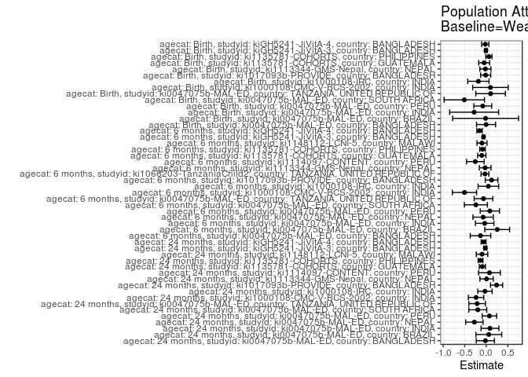

## Results Table

### Parameter: TSM

| agecat | studyid | country | intervention_level | baseline_level | estimate | ci_lower | ci_upper |
| --- | --- | --- | --- | --- | --- | --- | --- |
| Birth | ki0047075b-MAL-ED | BANGLADESH | Wealth Q4 | NA | -0.9683521 | -1.2110935 | -0.7256106 |
| Birth | ki0047075b-MAL-ED | BANGLADESH | Wealth Q1 | NA | -0.7455194 | -1.0559819 | -0.4350568 |
| Birth | ki0047075b-MAL-ED | BANGLADESH | Wealth Q2 | NA | -1.1143437 | -1.4123402 | -0.8163472 |
| Birth | ki0047075b-MAL-ED | BANGLADESH | Wealth Q3 | NA | -0.9970170 | -1.3455530 | -0.6484810 |
| Birth | ki0047075b-MAL-ED | BRAZIL | Wealth Q4 | NA | 0.4803185 | -0.3936300 | 1.3542669 |
| Birth | ki0047075b-MAL-ED | BRAZIL | Wealth Q1 | NA | 0.4410995 | -0.2035862 | 1.0857852 |
| Birth | ki0047075b-MAL-ED | BRAZIL | Wealth Q2 | NA | 0.8874174 | 0.4456607 | 1.3291742 |
| Birth | ki0047075b-MAL-ED | BRAZIL | Wealth Q3 | NA | 0.6024380 | 0.0295552 | 1.1753209 |
| Birth | ki0047075b-MAL-ED | INDIA | Wealth Q4 | NA | -0.6625000 | -1.2946579 | -0.0303421 |
| Birth | ki0047075b-MAL-ED | INDIA | Wealth Q1 | NA | -0.7753846 | -1.2462747 | -0.3044945 |
| Birth | ki0047075b-MAL-ED | INDIA | Wealth Q2 | NA | -1.2233333 | -1.8175527 | -0.6291139 |
| Birth | ki0047075b-MAL-ED | INDIA | Wealth Q3 | NA | -1.1588889 | -1.7968865 | -0.5208913 |
| Birth | ki0047075b-MAL-ED | PERU | Wealth Q4 | NA | 0.0343909 | -0.1934840 | 0.2622658 |
| Birth | ki0047075b-MAL-ED | PERU | Wealth Q1 | NA | -0.0998835 | -0.3547020 | 0.1549351 |
| Birth | ki0047075b-MAL-ED | PERU | Wealth Q2 | NA | 0.0980781 | -0.1549657 | 0.3511219 |
| Birth | ki0047075b-MAL-ED | PERU | Wealth Q3 | NA | -0.1034722 | -0.3898474 | 0.1829029 |
| Birth | ki0047075b-MAL-ED | SOUTH AFRICA | Wealth Q4 | NA | 0.3371415 | -0.1465468 | 0.8208297 |
| Birth | ki0047075b-MAL-ED | SOUTH AFRICA | Wealth Q1 | NA | -0.3308738 | -0.8037519 | 0.1420043 |
| Birth | ki0047075b-MAL-ED | SOUTH AFRICA | Wealth Q2 | NA | 0.0446803 | -0.4201032 | 0.5094638 |
| Birth | ki0047075b-MAL-ED | SOUTH AFRICA | Wealth Q3 | NA | -0.2693392 | -0.7812566 | 0.2425781 |
| Birth | ki0047075b-MAL-ED | TANZANIA, UNITED REPUBLIC OF | Wealth Q4 | NA | 0.6626505 | 0.2747270 | 1.0505741 |
| Birth | ki0047075b-MAL-ED | TANZANIA, UNITED REPUBLIC OF | Wealth Q1 | NA | 0.7912621 | 0.4700185 | 1.1125057 |
| Birth | ki0047075b-MAL-ED | TANZANIA, UNITED REPUBLIC OF | Wealth Q2 | NA | 0.7670235 | 0.3726418 | 1.1614052 |
| Birth | ki0047075b-MAL-ED | TANZANIA, UNITED REPUBLIC OF | Wealth Q3 | NA | 0.6303036 | 0.2481596 | 1.0124475 |
| Birth | ki1000108-CMC-V-BCS-2002 | INDIA | Wealth Q4 | NA | -0.5618467 | -1.1433506 | 0.0196572 |
| Birth | ki1000108-CMC-V-BCS-2002 | INDIA | Wealth Q1 | NA | -0.5232813 | -1.1975420 | 0.1509793 |
| Birth | ki1000108-CMC-V-BCS-2002 | INDIA | Wealth Q2 | NA | -0.6046906 | -1.1842740 | -0.0251073 |
| Birth | ki1000108-CMC-V-BCS-2002 | INDIA | Wealth Q3 | NA | -0.1332664 | -0.6620274 | 0.3954946 |
| Birth | ki1000108-IRC | INDIA | Wealth Q4 | NA | -0.8284678 | -1.1084997 | -0.5484359 |
| Birth | ki1000108-IRC | INDIA | Wealth Q1 | NA | -1.3202020 | -1.6394866 | -1.0009175 |

[output cut: 166 more lines]

### Parameter: E(Y)

| agecat | studyid | country | intervention_level | baseline_level | estimate | ci_lower | ci_upper |
| --- | --- | --- | --- | --- | --- | --- | --- |
| Birth | ki0047075b-MAL-ED | BANGLADESH | NA | NA | -0.9728358 | -1.1217009 | -0.8239707 |
| Birth | ki0047075b-MAL-ED | BRAZIL | NA | NA | 0.4643860 | 0.1360519 | 0.7927200 |
| Birth | ki0047075b-MAL-ED | INDIA | NA | NA | -0.9441026 | -1.2397919 | -0.6484132 |
| Birth | ki0047075b-MAL-ED | PERU | NA | NA | -0.0468095 | -0.1738806 | 0.0802616 |
| Birth | ki0047075b-MAL-ED | SOUTH AFRICA | NA | NA | -0.1729474 | -0.4186222 | 0.0727275 |
| Birth | ki0047075b-MAL-ED | TANZANIA, UNITED REPUBLIC OF | NA | NA | 0.7637500 | 0.5676177 | 0.9598823 |
| Birth | ki1000108-CMC-V-BCS-2002 | INDIA | NA | NA | -0.4648256 | -0.7643210 | -0.1653302 |
| Birth | ki1000108-IRC | INDIA | NA | NA | -1.0105831 | -1.1973019 | -0.8238643 |
| Birth | ki1017093b-PROVIDE | BANGLADESH | NA | NA | -1.2984586 | -1.3752758 | -1.2216415 |
| Birth | ki1113344-GMS-Nepal | NEPAL | NA | NA | -1.1164431 | -1.2040134 | -1.0288728 |
| Birth | ki1135781-COHORTS | GUATEMALA | NA | NA | -1.0572840 | -1.1606089 | -0.9539590 |
| Birth | ki1135781-COHORTS | PHILIPPINES | NA | NA | -0.7422912 | -0.7886598 | -0.6959226 |
| Birth | kiGH5241-JiVitA-3 | BANGLADESH | NA | NA | -0.7777103 | -0.7967006 | -0.7587201 |
| Birth | kiGH5241-JiVitA-4 | BANGLADESH | NA | NA | -0.6882498 | -0.7406539 | -0.6358456 |
| 6 months | ki0047075b-MAL-ED | BANGLADESH | NA | NA | -0.1333333 | -0.2623761 | -0.0042906 |
| 6 months | ki0047075b-MAL-ED | BRAZIL | NA | NA | 0.9720774 | 0.8078144 | 1.1363403 |
| 6 months | ki0047075b-MAL-ED | INDIA | NA | NA | -0.7102872 | -0.8371659 | -0.5834085 |
| 6 months | ki0047075b-MAL-ED | NEPAL | NA | NA | 0.1104308 | -0.0208643 | 0.2417259 |
| 6 months | ki0047075b-MAL-ED | PERU | NA | NA | 1.0512099 | 0.9285617 | 1.1738581 |
| 6 months | ki0047075b-MAL-ED | SOUTH AFRICA | NA | NA | 0.5404351 | 0.3867005 | 0.6941696 |
| 6 months | ki0047075b-MAL-ED | TANZANIA, UNITED REPUBLIC OF | NA | NA | 0.5362213 | 0.4049390 | 0.6675036 |
| 6 months | ki1000108-CMC-V-BCS-2002 | INDIA | NA | NA | -0.5026766 | -0.6536848 | -0.3516685 |
| 6 months | ki1000108-IRC | INDIA | NA | NA | -0.5989297 | -0.7344491 | -0.4634104 |
| 6 months | ki1017093b-PROVIDE | BANGLADESH | NA | NA | -0.1990907 | -0.2817968 | -0.1163845 |
| 6 months | ki1066203-TanzaniaChild2 | TANZANIA, UNITED REPUBLIC OF | NA | NA | 0.0801680 | 0.0273223 | 0.1330136 |
| 6 months | ki1113344-GMS-Nepal | NEPAL | NA | NA | -0.6038416 | -0.6899448 | -0.5177384 |
| 6 months | ki1114097-CONTENT | PERU | NA | NA | 1.0684318 | 0.9515274 | 1.1853362 |
| 6 months | ki1135781-COHORTS | GUATEMALA | NA | NA | 0.1914471 | 0.1185005 | 0.2643936 |
| 6 months | ki1135781-COHORTS | PHILIPPINES | NA | NA | -0.2938433 | -0.3352064 | -0.2524802 |
| 6 months | ki1148112-LCNI-5 | MALAWI | NA | NA | 0.4417647 | 0.3702742 | 0.5132552 |
| 6 months | kiGH5241-JiVitA-3 | BANGLADESH | NA | NA | -0.5932502 | -0.6127743 | -0.5737261 |
| 6 months | kiGH5241-JiVitA-4 | BANGLADESH | NA | NA | -0.3901595 | -0.4274150 | -0.3529041 |
| 24 months | ki0047075b-MAL-ED | BANGLADESH | NA | NA | -0.8192925 | -0.9412667 | -0.6973182 |
| 24 months | ki0047075b-MAL-ED | BRAZIL | NA | NA | 0.4626233 | 0.2567495 | 0.6684971 |
| 24 months | ki0047075b-MAL-ED | INDIA | NA | NA | -0.9516520 | -1.0670654 | -0.8362385 |
| 24 months | ki0047075b-MAL-ED | NEPAL | NA | NA | -0.3749123 | -0.4886073 | -0.2612173 |
| 24 months | ki0047075b-MAL-ED | PERU | NA | NA | 0.1111982 | -0.0118399 | 0.2342362 |
| 24 months | ki0047075b-MAL-ED | SOUTH AFRICA | NA | NA | 0.4090301 | 0.2879441 | 0.5301161 |
| 24 months | ki0047075b-MAL-ED | TANZANIA, UNITED REPUBLIC OF | NA | NA | 0.0547975 | -0.0703378 | 0.1799328 |
| 24 months | ki1000108-CMC-V-BCS-2002 | INDIA | NA | NA | -0.5571505 | -0.6585247 | -0.4557763 |
| 24 months | ki1000108-IRC | INDIA | NA | NA | -0.7458150 | -0.8368180 | -0.6548120 |
| 24 months | ki1017093b-PROVIDE | BANGLADESH | NA | NA | -0.8928670 | -0.9755153 | -0.8102187 |
| 24 months | ki1113344-GMS-Nepal | NEPAL | NA | NA | -1.1363107 | -1.2252817 | -1.0473398 |
| 24 months | ki1114097-CONTENT | PERU | NA | NA | 0.5668293 | 0.4302437 | 0.7034148 |
| 24 months | ki1135781-COHORTS | GUATEMALA | NA | NA | -0.2791396 | -0.3336899 | -0.2245893 |
| 24 months | ki1135781-COHORTS | PHILIPPINES | NA | NA | -0.6099592 | -0.6467541 | -0.5731643 |
| 24 months | ki1148112-LCNI-5 | MALAWI | NA | NA | -0.0477867 | -0.1301103 | 0.0345368 |
| 24 months | kiGH5241-JiVitA-3 | BANGLADESH | NA | NA | -1.2973086 | -1.3206115 | -1.2740057 |
| 24 months | kiGH5241-JiVitA-4 | BANGLADESH | NA | NA | -1.2231776 | -1.2550332 | -1.1913220 |

### Parameter: ATE

| agecat | studyid | country | intervention_level | baseline_level | estimate | ci_lower | ci_upper |
| --- | --- | --- | --- | --- | --- | --- | --- |
| Birth | ki0047075b-MAL-ED | BANGLADESH | Wealth Q4 | Wealth Q4 | 0.0000000 | 0.0000000 | 0.0000000 |
| Birth | ki0047075b-MAL-ED | BANGLADESH | Wealth Q1 | Wealth Q4 | 0.2228327 | -0.1715412 | 0.6172065 |
| Birth | ki0047075b-MAL-ED | BANGLADESH | Wealth Q2 | Wealth Q4 | -0.1459916 | -0.5313326 | 0.2393494 |
| Birth | ki0047075b-MAL-ED | BANGLADESH | Wealth Q3 | Wealth Q4 | -0.0286650 | -0.4540888 | 0.3967588 |
| Birth | ki0047075b-MAL-ED | BRAZIL | Wealth Q4 | Wealth Q4 | 0.0000000 | 0.0000000 | 0.0000000 |
| Birth | ki0047075b-MAL-ED | BRAZIL | Wealth Q1 | Wealth Q4 | -0.0392190 | -1.1168984 | 1.0384604 |
| Birth | ki0047075b-MAL-ED | BRAZIL | Wealth Q2 | Wealth Q4 | 0.4070990 | -0.5563176 | 1.3705155 |
| Birth | ki0047075b-MAL-ED | BRAZIL | Wealth Q3 | Wealth Q4 | 0.1221196 | -0.9097593 | 1.1539984 |
| Birth | ki0047075b-MAL-ED | INDIA | Wealth Q4 | Wealth Q4 | 0.0000000 | 0.0000000 | 0.0000000 |
| Birth | ki0047075b-MAL-ED | INDIA | Wealth Q1 | Wealth Q4 | -0.1128846 | -0.9011492 | 0.6753800 |
| Birth | ki0047075b-MAL-ED | INDIA | Wealth Q2 | Wealth Q4 | -0.5608333 | -1.4284279 | 0.3067612 |
| Birth | ki0047075b-MAL-ED | INDIA | Wealth Q3 | Wealth Q4 | -0.4963889 | -1.3945340 | 0.4017562 |
| Birth | ki0047075b-MAL-ED | PERU | Wealth Q4 | Wealth Q4 | 0.0000000 | 0.0000000 | 0.0000000 |
| Birth | ki0047075b-MAL-ED | PERU | Wealth Q1 | Wealth Q4 | -0.1342744 | -0.4766555 | 0.2081068 |
| Birth | ki0047075b-MAL-ED | PERU | Wealth Q2 | Wealth Q4 | 0.0636872 | -0.2770192 | 0.4043937 |
| Birth | ki0047075b-MAL-ED | PERU | Wealth Q3 | Wealth Q4 | -0.1378631 | -0.5051853 | 0.2294591 |
| Birth | ki0047075b-MAL-ED | SOUTH AFRICA | Wealth Q4 | Wealth Q4 | 0.0000000 | 0.0000000 | 0.0000000 |
| Birth | ki0047075b-MAL-ED | SOUTH AFRICA | Wealth Q1 | Wealth Q4 | -0.6680152 | -1.3491976 | 0.0131671 |
| Birth | ki0047075b-MAL-ED | SOUTH AFRICA | Wealth Q2 | Wealth Q4 | -0.2924612 | -0.9612943 | 0.3763720 |
| Birth | ki0047075b-MAL-ED | SOUTH AFRICA | Wealth Q3 | Wealth Q4 | -0.6064807 | -1.3146488 | 0.1016874 |
| Birth | ki0047075b-MAL-ED | TANZANIA, UNITED REPUBLIC OF | Wealth Q4 | Wealth Q4 | 0.0000000 | 0.0000000 | 0.0000000 |
| Birth | ki0047075b-MAL-ED | TANZANIA, UNITED REPUBLIC OF | Wealth Q1 | Wealth Q4 | 0.1286116 | -0.3564298 | 0.6136530 |
| Birth | ki0047075b-MAL-ED | TANZANIA, UNITED REPUBLIC OF | Wealth Q2 | Wealth Q4 | 0.1043730 | -0.4368883 | 0.6456342 |
| Birth | ki0047075b-MAL-ED | TANZANIA, UNITED REPUBLIC OF | Wealth Q3 | Wealth Q4 | -0.0323470 | -0.5655561 | 0.5008622 |
| Birth | ki1000108-CMC-V-BCS-2002 | INDIA | Wealth Q4 | Wealth Q4 | 0.0000000 | 0.0000000 | 0.0000000 |
| Birth | ki1000108-CMC-V-BCS-2002 | INDIA | Wealth Q1 | Wealth Q4 | 0.0385654 | -0.8483416 | 0.9254724 |
| Birth | ki1000108-CMC-V-BCS-2002 | INDIA | Wealth Q2 | Wealth Q4 | -0.0428439 | -0.8662783 | 0.7805904 |
| Birth | ki1000108-CMC-V-BCS-2002 | INDIA | Wealth Q3 | Wealth Q4 | 0.4285803 | -0.3563376 | 1.2134981 |
| Birth | ki1000108-IRC | INDIA | Wealth Q4 | Wealth Q4 | 0.0000000 | 0.0000000 | 0.0000000 |
| Birth | ki1000108-IRC | INDIA | Wealth Q1 | Wealth Q4 | -0.4917342 | -0.8929035 | -0.0905650 |

[output cut: 166 more lines]

### Parameter: PAR

| agecat | studyid | country | intervention_level | baseline_level | estimate | ci_lower | ci_upper |
| --- | --- | --- | --- | --- | --- | --- | --- |
| Birth | ki0047075b-MAL-ED | BANGLADESH | Wealth Q4 | NA | -0.0044838 | -0.2248958 | 0.2159283 |
| Birth | ki0047075b-MAL-ED | BRAZIL | Wealth Q4 | NA | -0.0159325 | -0.7810481 | 0.7491831 |
| Birth | ki0047075b-MAL-ED | INDIA | Wealth Q4 | NA | -0.2816026 | -0.8500282 | 0.2868230 |
| Birth | ki0047075b-MAL-ED | PERU | Wealth Q4 | NA | -0.0812004 | -0.2875345 | 0.1251337 |
| Birth | ki0047075b-MAL-ED | SOUTH AFRICA | Wealth Q4 | NA | -0.5100888 | -0.9779121 | -0.0422656 |
| Birth | ki0047075b-MAL-ED | TANZANIA, UNITED REPUBLIC OF | Wealth Q4 | NA | 0.1010995 | -0.2423495 | 0.4445484 |
| Birth | ki1000108-CMC-V-BCS-2002 | INDIA | Wealth Q4 | NA | 0.0970211 | -0.3151053 | 0.5091476 |
| Birth | ki1000108-IRC | INDIA | Wealth Q4 | NA | -0.1821153 | -0.4290131 | 0.0647825 |
| Birth | ki1017093b-PROVIDE | BANGLADESH | Wealth Q4 | NA | -0.0139810 | -0.1309581 | 0.1029960 |
| Birth | ki1113344-GMS-Nepal | NEPAL | Wealth Q4 | NA | -0.0198346 | -0.1491227 | 0.1094535 |
| Birth | ki1135781-COHORTS | GUATEMALA | Wealth Q4 | NA | -0.0491182 | -0.1763313 | 0.0780948 |
| Birth | ki1135781-COHORTS | PHILIPPINES | Wealth Q4 | NA | 0.0604924 | -0.0106108 | 0.1315955 |
| Birth | kiGH5241-JiVitA-3 | BANGLADESH | Wealth Q4 | NA | -0.0077021 | -0.0384193 | 0.0230151 |
| Birth | kiGH5241-JiVitA-4 | BANGLADESH | Wealth Q4 | NA | -0.0224574 | -0.1072316 | 0.0623167 |
| 6 months | ki0047075b-MAL-ED | BANGLADESH | Wealth Q4 | NA | -0.1333157 | -0.3713518 | 0.1047205 |
| 6 months | ki0047075b-MAL-ED | BRAZIL | Wealth Q4 | NA | 0.2535570 | -0.0348435 | 0.5419574 |
| 6 months | ki0047075b-MAL-ED | INDIA | Wealth Q4 | NA | -0.0367911 | -0.2508911 | 0.1773090 |
| 6 months | ki0047075b-MAL-ED | NEPAL | Wealth Q4 | NA | -0.0728093 | -0.3091791 | 0.1635605 |
| 6 months | ki0047075b-MAL-ED | PERU | Wealth Q4 | NA | 0.0828553 | -0.1405965 | 0.3063072 |
| 6 months | ki0047075b-MAL-ED | SOUTH AFRICA | Wealth Q4 | NA | -0.2407832 | -0.5083417 | 0.0267754 |
| 6 months | ki0047075b-MAL-ED | TANZANIA, UNITED REPUBLIC OF | Wealth Q4 | NA | -0.0642591 | -0.2810287 | 0.1525105 |
| 6 months | ki1000108-CMC-V-BCS-2002 | INDIA | Wealth Q4 | NA | -0.5049672 | -0.7863898 | -0.2235446 |
| 6 months | ki1000108-IRC | INDIA | Wealth Q4 | NA | 0.0489913 | -0.1897624 | 0.2877450 |
| 6 months | ki1017093b-PROVIDE | BANGLADESH | Wealth Q4 | NA | 0.1232930 | -0.0237951 | 0.2703812 |
| 6 months | ki1066203-TanzaniaChild2 | TANZANIA, UNITED REPUBLIC OF | Wealth Q4 | NA | -0.0295326 | -0.1210906 | 0.0620254 |
| 6 months | ki1113344-GMS-Nepal | NEPAL | Wealth Q4 | NA | -0.0259375 | -0.1620380 | 0.1101629 |
| 6 months | ki1114097-CONTENT | PERU | Wealth Q4 | NA | -0.2535506 | -0.4571524 | -0.0499488 |
| 6 months | ki1135781-COHORTS | GUATEMALA | Wealth Q4 | NA | -0.1036988 | -0.1991890 | -0.0082087 |
| 6 months | ki1135781-COHORTS | PHILIPPINES | Wealth Q4 | NA | -0.0883784 | -0.1524560 | -0.0243008 |
| 6 months | ki1148112-LCNI-5 | MALAWI | Wealth Q4 | NA | -0.0994908 | -0.2154035 | 0.0164219 |
| 6 months | kiGH5241-JiVitA-3 | BANGLADESH | Wealth Q4 | NA | -0.0649146 | -0.0937618 | -0.0360673 |
| 6 months | kiGH5241-JiVitA-4 | BANGLADESH | Wealth Q4 | NA | -0.1561214 | -0.2186919 | -0.0935509 |
| 24 months | ki0047075b-MAL-ED | BANGLADESH | Wealth Q4 | NA | -0.0208418 | -0.2320508 | 0.1903671 |
| 24 months | ki0047075b-MAL-ED | BRAZIL | Wealth Q4 | NA | 0.0593930 | -0.2402422 | 0.3590282 |
| 24 months | ki0047075b-MAL-ED | INDIA | Wealth Q4 | NA | 0.0861461 | -0.1211825 | 0.2934747 |
| 24 months | ki0047075b-MAL-ED | NEPAL | Wealth Q4 | NA | -0.2762805 | -0.4782842 | -0.0742767 |
| 24 months | ki0047075b-MAL-ED | PERU | Wealth Q4 | NA | 0.0734676 | -0.0955213 | 0.2424566 |
| 24 months | ki0047075b-MAL-ED | SOUTH AFRICA | Wealth Q4 | NA | -0.1963746 | -0.4045466 | 0.0117974 |
| 24 months | ki0047075b-MAL-ED | TANZANIA, UNITED REPUBLIC OF | Wealth Q4 | NA | -0.2116561 | -0.4038492 | -0.0194630 |
| 24 months | ki1000108-CMC-V-BCS-2002 | INDIA | Wealth Q4 | NA | -0.2366619 | -0.4155952 | -0.0577286 |
| 24 months | ki1000108-IRC | INDIA | Wealth Q4 | NA | -0.0304079 | -0.1973156 | 0.1364997 |
| 24 months | ki1017093b-PROVIDE | BANGLADESH | Wealth Q4 | NA | 0.2395440 | 0.0986222 | 0.3804658 |
| 24 months | ki1113344-GMS-Nepal | NEPAL | Wealth Q4 | NA | 0.0065586 | -0.1479477 | 0.1610650 |
| 24 months | ki1114097-CONTENT | PERU | Wealth Q4 | NA | 0.0739599 | -0.1788259 | 0.3267457 |
| 24 months | ki1135781-COHORTS | GUATEMALA | Wealth Q4 | NA | -0.0915019 | -0.1617017 | -0.0213021 |
| 24 months | ki1135781-COHORTS | PHILIPPINES | Wealth Q4 | NA | -0.1327207 | -0.1888928 | -0.0765486 |
| 24 months | ki1148112-LCNI-5 | MALAWI | Wealth Q4 | NA | -0.0978645 | -0.2309275 | 0.0351985 |
| 24 months | kiGH5241-JiVitA-3 | BANGLADESH | Wealth Q4 | NA | -0.0228169 | -0.0585890 | 0.0129552 |
| 24 months | kiGH5241-JiVitA-4 | BANGLADESH | Wealth Q4 | NA | -0.0618980 | -0.1186742 | -0.0051218 |